# Exploratory Data Analysis

### Chapter 5

```r
library(tidyverse)
```

** 90-1 ** Explore the distribution of each of the x, y, and z variables in diamonds. What do you learn? Think about a diamond and how you might decide which dimension is the length, width, and depth.

```r
# pull each column for histogram analysis and remove outliers using thresholds
x = diamonds %>% select(x) %>% filter(x > 2 & x < 20)
y = diamonds %>% select(y) %>% filter(y > 2 & y < 20)
z = diamonds %>% select(z) %>% filter(z > 2 & z < 20)
```

```r
summary(x)
```

```
##        x
##  Min.   : 3.730
##  1st Qu.: 4.710
##  Median : 5.700
##  Mean   : 5.732
##  3rd Qu.: 6.540
##  Max.   :10.740
```

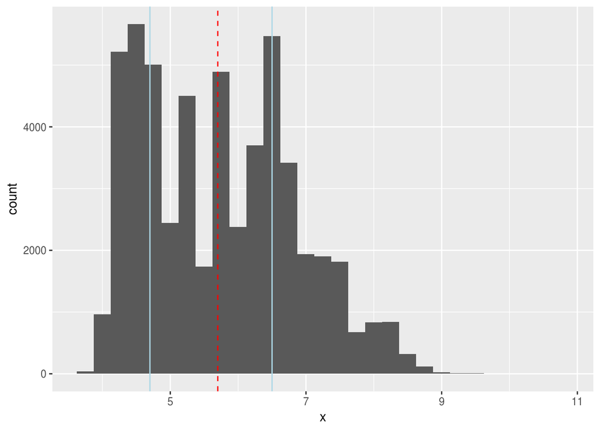

```r
ggplot(data=x) + geom_histogram(binwidth = 0.25,aes(x=x)) +
    geom_vline(xintercept=5.7,colour='red', linetype=2) + # mean and median almost the same
    geom_vline(xintercept=4.7, colour='light blue') +
    geom_vline(xintercept=6.5, colour='light blue')
```

```r
summary(y)
```

```
##        y
##  Min.   : 3.680
##  1st Qu.: 4.720
##  Median : 5.710
##  Mean   : 5.734
##  3rd Qu.: 6.540
##  Max.   :10.540
```

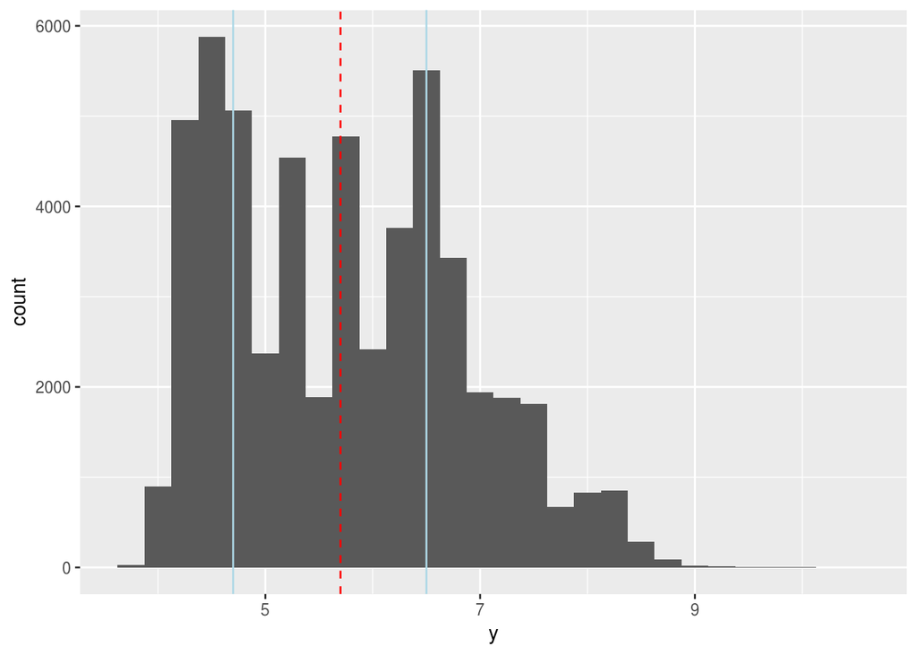

```r
ggplot(data=y) + geom_histogram(binwidth = 0.25,aes(x=y)) +
    geom_vline(xintercept=5.7,color='red', linetype=2) + # mean and median almost the same
    geom_vline(xintercept=4.7, colour='light blue') +
    geom_vline(xintercept=6.5, colour='light blue')
```

```r
summary(z)
```

```
##        z
##  Min.   :2.06
##  1st Qu.:2.91
##  Median :3.53
##  Mean   :3.54
##  3rd Qu.:4.04
##  Max.   :8.06
```

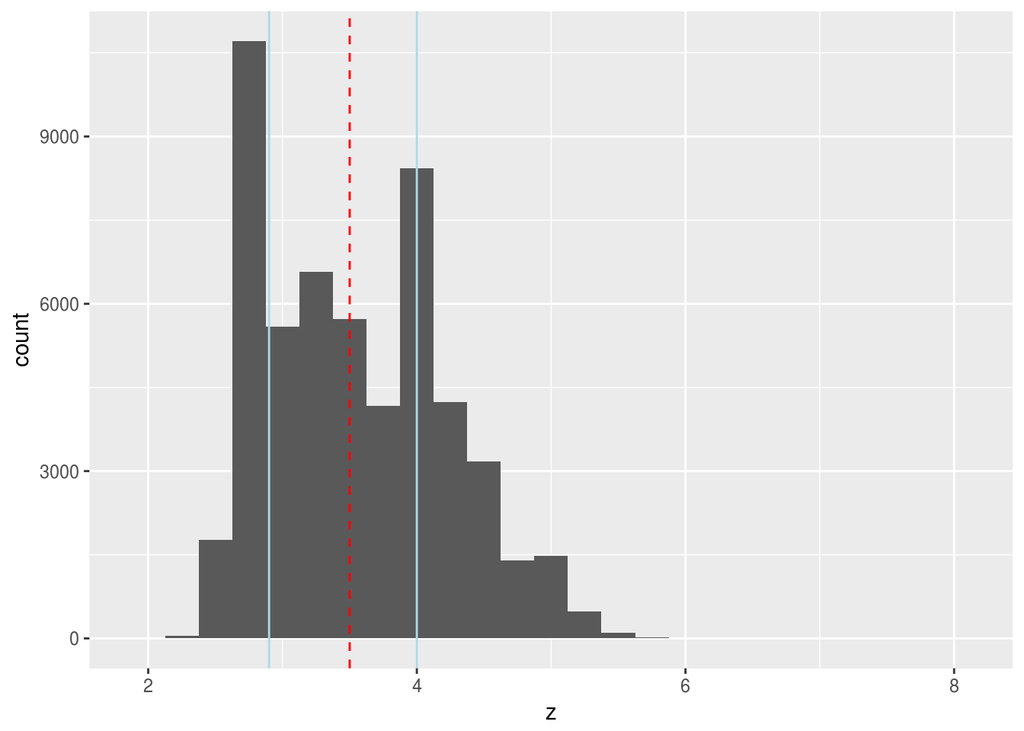

```r
ggplot(data=z) + geom_histogram(binwidth = 0.25,aes(x=z)) +
    geom_vline(xintercept=3.5, colour='red', linetype=2) + # mean and median almost the same
    geom_vline(xintercept=2.9, colour='light blue') +
    geom_vline(xintercept=4.0, colour='light blue')
```

**91-2**

Explore the distribution of price. Do you discover anything unusual or surprising? (Hint: Carefully think about the binwidth and make sure you try a wide range of values.)

```r
price = diamonds %>% select(price) %>% filter(price > 100 & !is.na(price))
```

```r
summary(price)
```

```
##      price
##  Min.   :  326
##  1st Qu.:  950
##  Median : 2401
##  Mean   : 3933
##  3rd Qu.: 5324
##  Max.   :18823
```

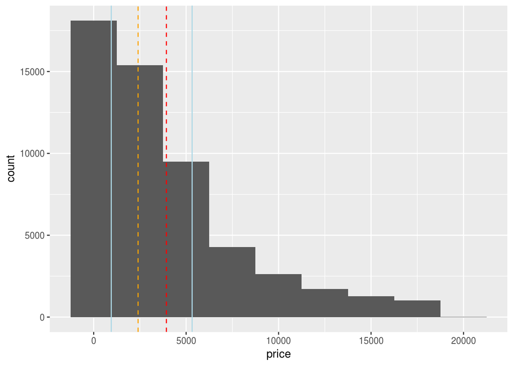

```r
ggplot(data=price) + geom_histogram(binwidth=2500,aes(x=price)) +
    geom_vline(xintercept=3933, colour='red', linetype=2) +  # mean
    geom_vline(xintercept=2401, colour='orange', linetype=2) + # median
    geom_vline(xintercept=950, colour='light blue') +
    geom_vline(xintercept=5324, colour='light blue')
```

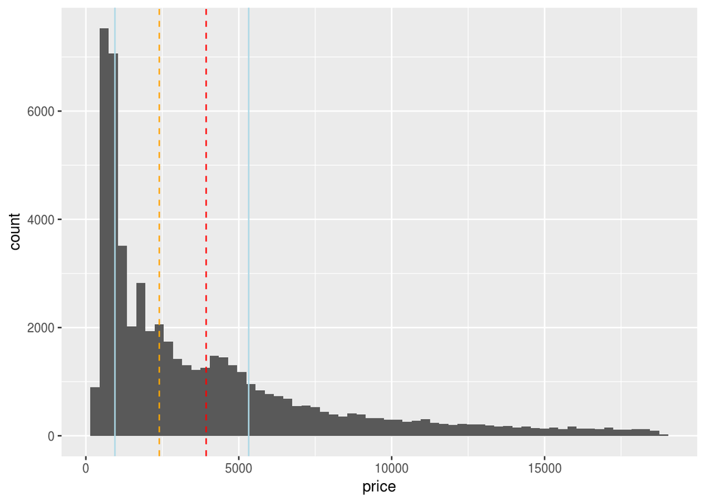

```r
ggplot(price) + geom_histogram(aes(x=price),binwidth=300)+
    geom_vline(xintercept=3933, colour='red', linetype=2) +  # mean
    geom_vline(xintercept=2401, colour='orange', linetype=2) +  # median
    geom_vline(xintercept=950, colour='light blue') +
    geom_vline(xintercept=5324, colour='light blue')
```

```r
summary(price)
```

```
##      price
##  Min.   :  326
##  1st Qu.:  950
##  Median : 2401
##  Mean   : 3933
##  3rd Qu.: 5324
##  Max.   :18823
```

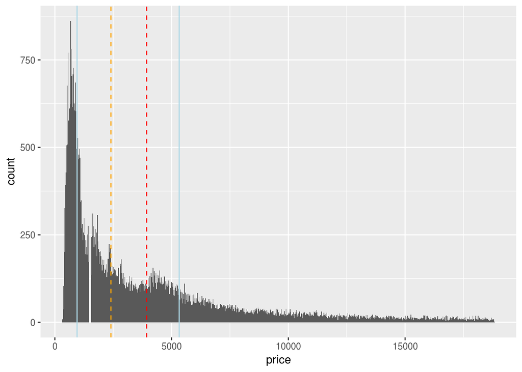

```r
ggplot(price) + geom_histogram(aes(x=price),binwidth=25)+
    geom_vline(xintercept=3933, colour='red', linetype=2) +  #mean
    geom_vline(xintercept=2401, colour='orange', linetype=2) + # median
    geom_vline(xintercept=950, colour='light blue') +
    geom_vline(xintercept=5324, colour='light blue')
```

The summary data and overall shape of the histogram shows a right skewed distribution. There is a higher frequency of prices below 1000.

**93-2**

What happens to missing values in a histogram? What happens to missing values in a bar chart? Why is there a difference?

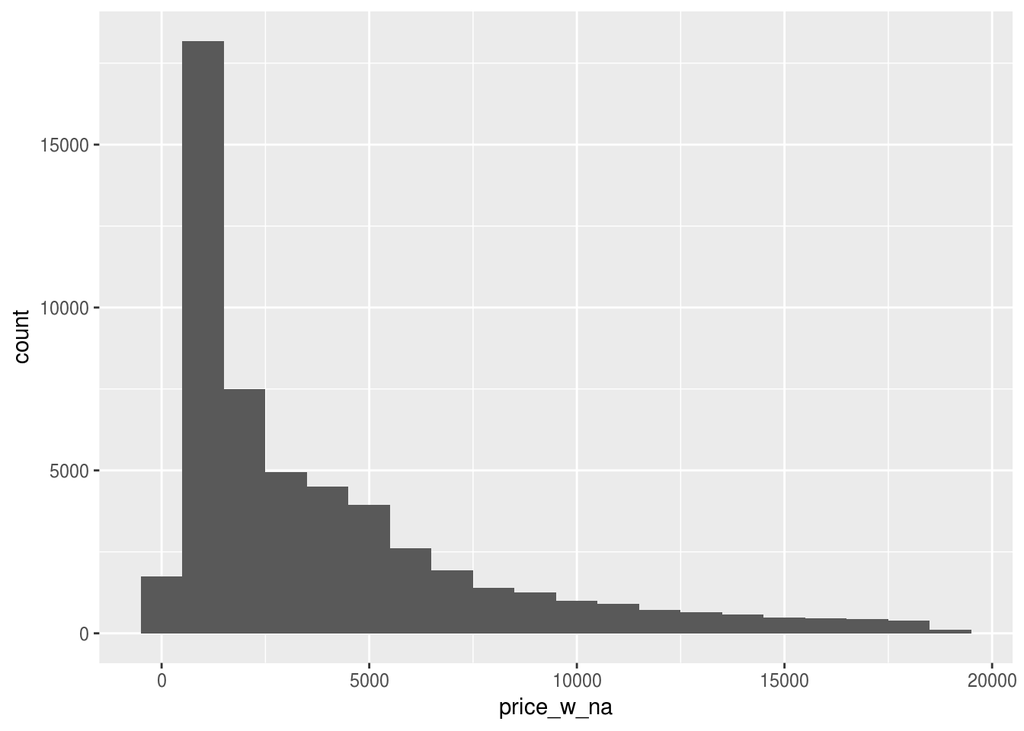

```r
# adding NAs randomly to see effect

na_idx = sample(1:53940, 200)
price_w_na = price
price_w_na[na_idx,] = NA

ggplot(data=price_w_na) + geom_histogram(aes(x=price_w_na),binwidth=1000)
```

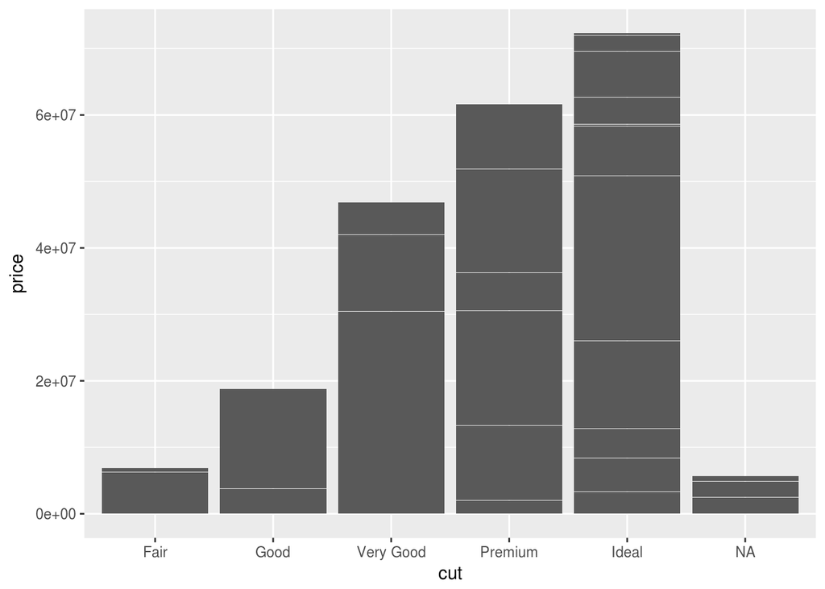

```r
cut_w_na = diamonds$cut
cut_w_na = addNA(cut_w_na)

na_idx = sample(1:53940, 1500)
cut_w_na[na_idx] = NA

df = data.frame(cut=cut_w_na, price=diamonds$price)

ggplot(data=df) +
    geom_histogram(aes(x=cut, y=price), stat='identity')
```

A histogram will remove any NAs before plotting since the graph represents the distribution of a single continuous variable and an NA is an undefined value.

A bar plot contains both categorical and continuous variables and if there are NAs in the factor, then NA is simply treated as another category.

**99-2**

What variable in the diamonds dataset is most important for predicting the price of a diamond? How is that variable correlated with cut? Why does the combination of those two relationships lead to lower quality diamonds being more expensive?

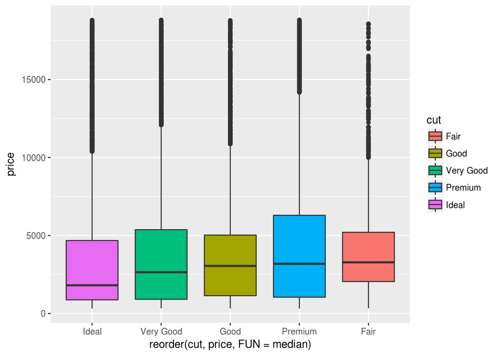

```r
ggplot(data = diamonds, mapping = aes(x=reorder(cut,price,FUN=median),y=price, fill=cut)) +
  geom_boxplot()
```

The original boxplot above shows the relationship between cut and price in the dataset. When reording based on median, we see that fair diamonds outperform all other cuts in the ordinal factor. This could be an indication that another variable that is positively correlated with price is also positively correlated with fair-cut diamonds.

Using cor() we see that carat and price are highly correlated. A regression analysis confirms that carat is predictive of price and a quick plot shows that these are positively correlated.

```r
cor(diamonds$carat, diamonds$price) # extreme correlation between carat and price
```

```
## [1] 0.9215913
```

```r
summary(lm(price~carat, data=diamonds))  # high R-squared here confirms a good prediction
```

```
##
## Call:
## lm(formula = price ~ carat, data = diamonds)
##
## Residuals:
##      Min       1Q   Median       3Q      Max
## -18585.3   -804.8    -18.9    537.4  12731.7
##
## Coefficients:
##             Estimate Std. Error t value Pr(>|t|)
## (Intercept) -2256.36      13.06  -172.8   <2e-16 ***
## carat        7756.43      14.07   551.4   <2e-16 ***
## ---
## Signif. codes:  0 '***' 0.001 '**' 0.01 '*' 0.05 '.' 0.1 ' ' 1
##
## Residual standard error: 1549 on 53938 degrees of freedom
## Multiple R-squared:  0.8493, Adjusted R-squared:  0.8493
## F-statistic: 3.041e+05 on 1 and 53938 DF,  p-value: < 2.2e-16
```

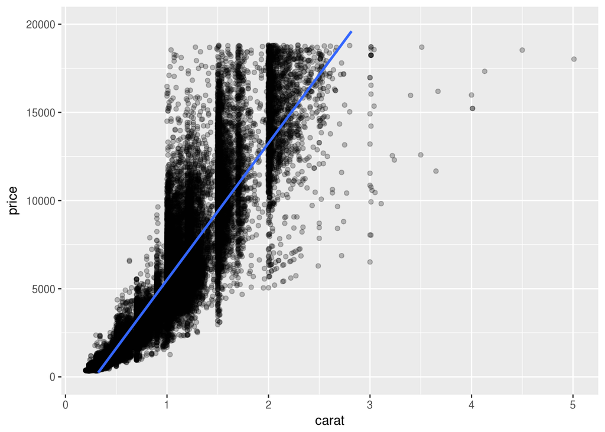

```r
ggplot(data = diamonds, mapping = aes(x = carat, y = price), alpha=1/100) +
    geom_point(alpha=.25) +
    geom_smooth(method='lm') + ylim(0,20000)
```

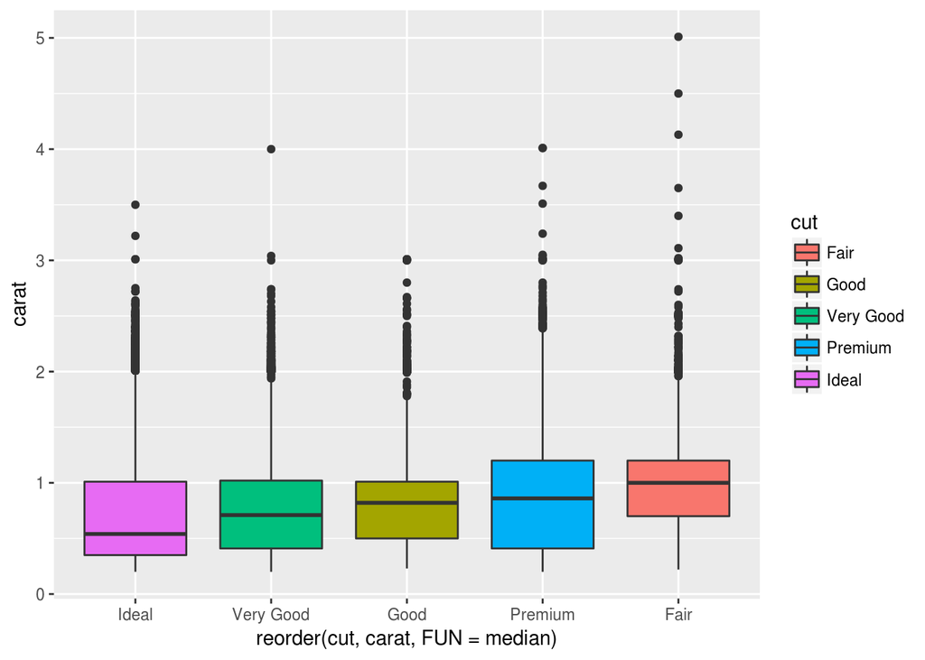

```r
# similar boxplot shows fair
ggplot(data=diamonds, aes(reorder(cut,carat,FUN=median),y=carat, fill=cut)) +
    geom_boxplot()
```

**104-3**

How does the price distribution of very large diamonds compare to small diamonds. Is it as you expect, or does it surprise you?

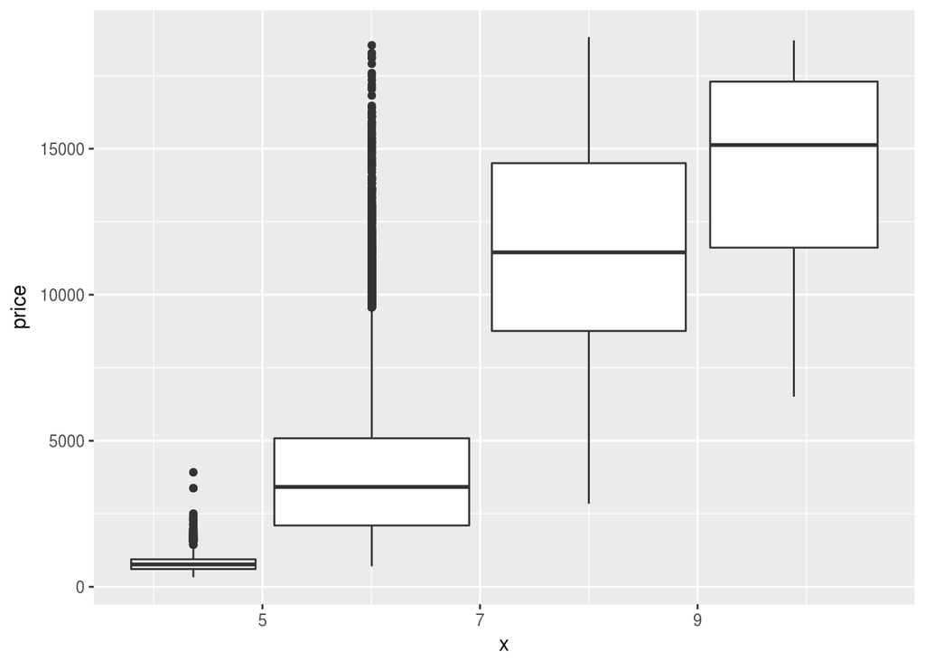

```r
diamonds1 = diamonds %>% filter(x> 2 & x< 20)

ggplot(data = diamonds1, mapping = aes(x = x, y = price)) +
    geom_boxplot(aes(group = cut_width(x, 2)))
```

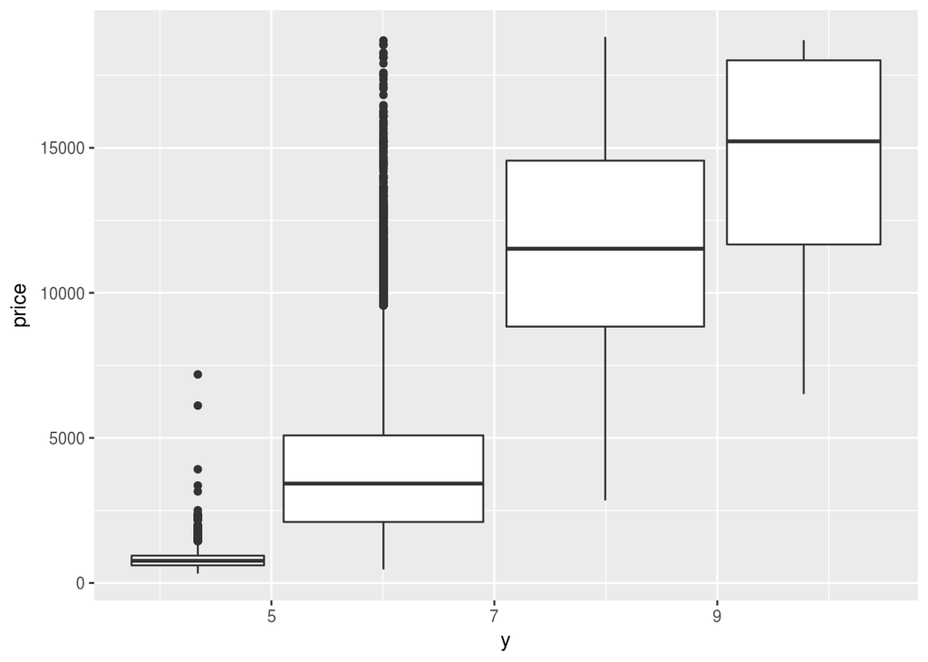

```r
diamonds2 = diamonds %>% filter(y > 2 & y < 20)

ggplot(data = diamonds2, mapping = aes(x = y, y = price)) +
    geom_boxplot(aes(group = cut_width(y, 2)))
```

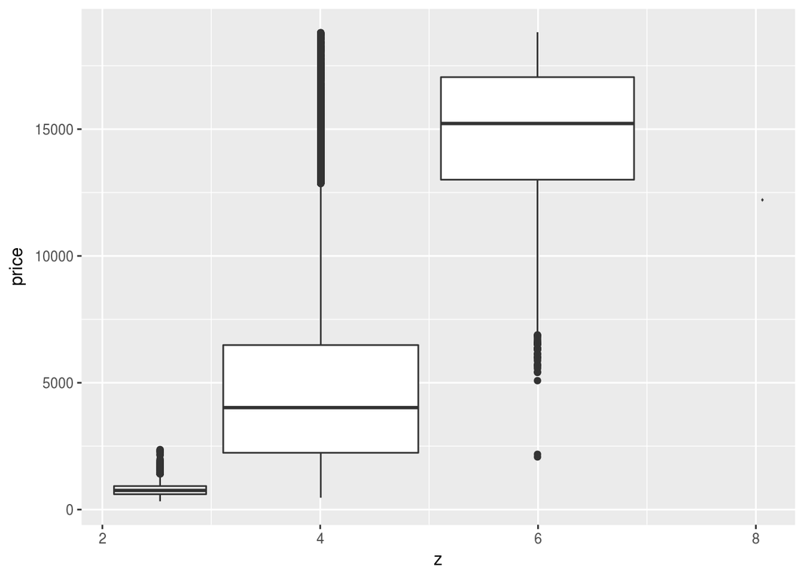

```r
diamonds3 = diamonds %>% filter(z > 2 & z < 20)

ggplot(data = diamonds3, mapping = aes(x = z, y = price)) +
    geom_boxplot(aes(group = cut_width(z, 2)))
```

After binning the dimension variables x, y and z, we can see that larger sized diamonds have a much wider price distribution than smaller diamonds.

This is not surprising since larger diamonds will most likely have the most variety in terms of color, clarity, cut and other characteristics.

**123-1** How can you tell if an object is a tibble?

Using the is.tibble() method.

```r
x = tibble()
y = 'not a tibble'

is.tibble(x)
```

```
## [1] TRUE
```

```r
is.tibble(y)
```

```
## [1] FALSE
```

**124-3** If you have the name of a variable stored in an object, e.g. var <- “mpg”, how can you extract the reference variable from a tibble?

Not exactly sure what this question is getting at, but this is how to get a variable out of dataframe. It will work on a tibble as well.

```r
tibble(var="mpg")$var
```

```
## [1] "mpg"
```